# Final Exam R

Ana Frandell

March 16, 2016

# Use date from NCY Flights 13

## Part A - Weather

```
##
## Call:
## lm(formula = weather.f$can ~ weather.f$humid)
##
## Coefficients:
##     (Intercept)  weather.f$humid
##      -2.033e-05        1.177e-05
```

```r
summary(weather.reg)
```

```
##
## Call:
## lm(formula = weather.f$can ~ weather.f$humid + weather.f$wind_speed +
##     weather.f$precip + weather.f$temp)
##
## Residuals:
##      Min       1Q   Median       3Q      Max
## -0.00139 -0.00089 -0.00072 -0.00053  0.99992
##
## Coefficients:
##                        Estimate Std. Error t value Pr(>|t|)
## (Intercept)           1.139e-04  4.652e-04   0.245  0.80665
## weather.f$humid       1.300e-05  4.764e-06   2.728  0.00636 **
## weather.f$wind_speed  5.759e-06  1.626e-05   0.354  0.72327
## weather.f$precip     -1.158e-03  4.716e-03  -0.246  0.80598
## weather.f$temp       -5.805e-06  5.855e-06  -0.991  0.32148
## ---
## Signif. codes:  0 '***' 0.001 '**' 0.01 '*' 0.05 '.' 0.1 ' ' 1
##
## Residual standard error: 0.02671 on 98010 degrees of freedom
##   (1985 observations deleted due to missingness)
## Multiple R-squared:  8.895e-05,  Adjusted R-squared:  4.814e-05
## F-statistic:  2.18 on 4 and 98010 DF,  p-value: 0.06853
```

```r
desc<-arrange(weather.f, desc(dep_delay))
head(desc$temp, 10)
```

```
##  [1] 33.98 39.92 48.02 39.02 24.98 24.98 26.96 50.00 64.04 35.60
```

Top 10 delayed flights by tempurature

```r
head(desc$wind_gust, n=10)
```

```
##  [1]  0.000000  7.945768  5.297178 13.242946  7.945768  5.297178 14.567241
##  [8]  6.621473  6.621473  7.945768
```

Top 10 delayed flights by wind gust

## Part B - Aspects of Time

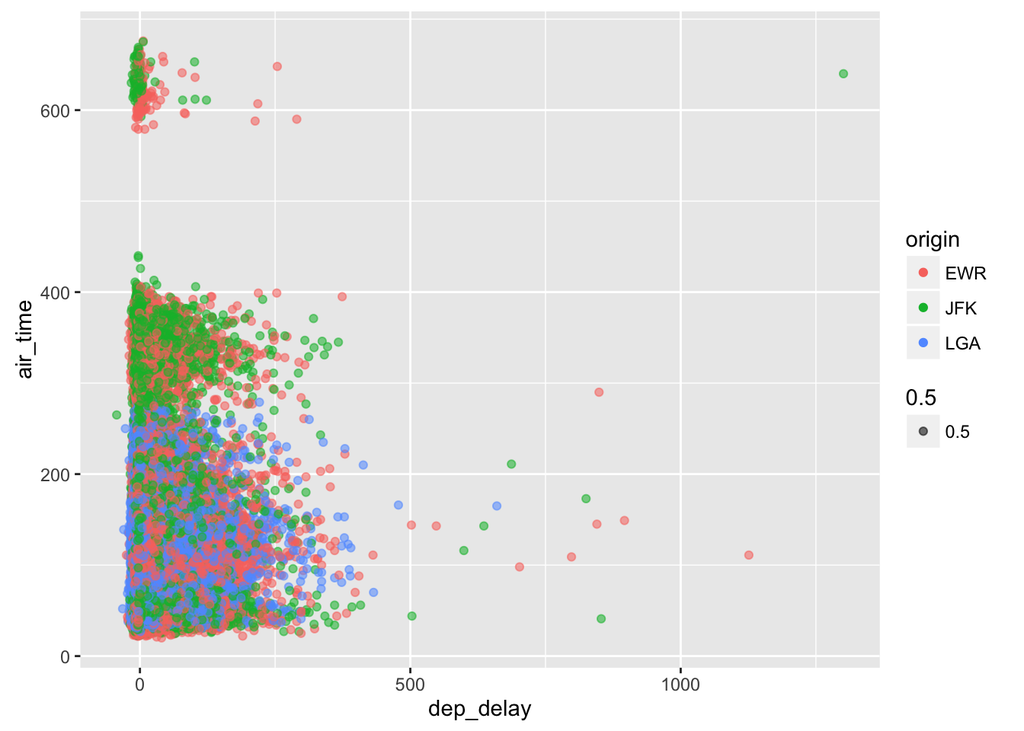

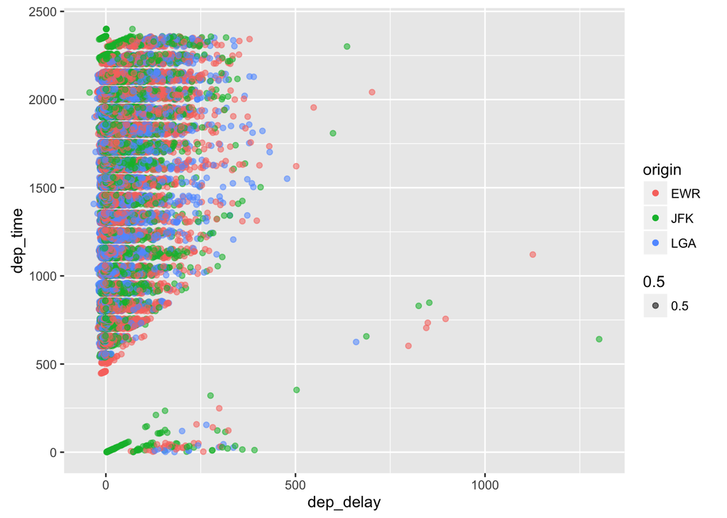

Departure Delay by Departure Times, ggplot

Depending on the origin, the flights that depart later in the day are more likely to experience departure delay.

```r
summary(flights.summary)
```

```
##      minute      flight.cancled.n flights.delay.n   delay.min
##  Min.   : 0.00   Min.   :   0.0   Min.   :    0   Min.   :-43.00
##  1st Qu.:14.75   1st Qu.:   0.0   1st Qu.:12823   1st Qu.:-20.00
##  Median :29.50   Median :   1.0   Median :15136   Median :-18.00
##  Mean   :29.50   Mean   :  32.2   Mean   :14107   Mean   :-18.55
##  3rd Qu.:44.25   3rd Qu.:   2.0   3rd Qu.:16241   3rd Qu.:-15.75
##  Max.   :59.00   Max.   :1894.0   Max.   :19071   Max.   :-12.00
##  NA's   :1                                        NA's   :1
##    delay.mean      delay.median      delay.max
##  Min.   : 2.029   Min.   :-7.000   Min.   : 229.0
##  1st Qu.: 7.203   1st Qu.:-3.000   1st Qu.: 316.8
##  Median :10.583   Median :-2.000   Median : 356.0
##  Mean   : 9.645   Mean   :-1.858   Mean   : 453.4
##  3rd Qu.:11.836   3rd Qu.: 0.000   3rd Qu.: 502.2
##  Max.   :14.060   Max.   : 2.000   Max.   :1301.0
##  NA's   :1        NA's   :1        NA's   :1
```

```r
hour.reg <- (lm(weather.f$can ~ weather.f$hour))
```

```r
summary(hour.reg)
```

```
##
## Call:
## lm(formula = weather.f$can ~ weather.f$hour)
##
## Residuals:
##      Min       1Q   Median       3Q      Max
## -0.00087 -0.00077 -0.00071 -0.00065  0.99940
##
## Coefficients:
##                 Estimate Std. Error t value Pr(>|t|)
## (Intercept)    5.262e-04  2.482e-04   2.120    0.034 *
## weather.f$hour 1.427e-05  1.776e-05   0.803    0.422
## ---
## Signif. codes:  0 '***' 0.001 '**' 0.01 '*' 0.05 '.' 0.1 ' ' 1
##
## Residual standard error: 0.0267 on 98104 degrees of freedom
##   (1894 observations deleted due to missingness)
## Multiple R-squared:  6.578e-06,  Adjusted R-squared:  -3.615e-06
## F-statistic: 0.6453 on 1 and 98104 DF,  p-value: 0.4218
```

This regression results shows that hours is not a statistically significant determinant for canceled flights.

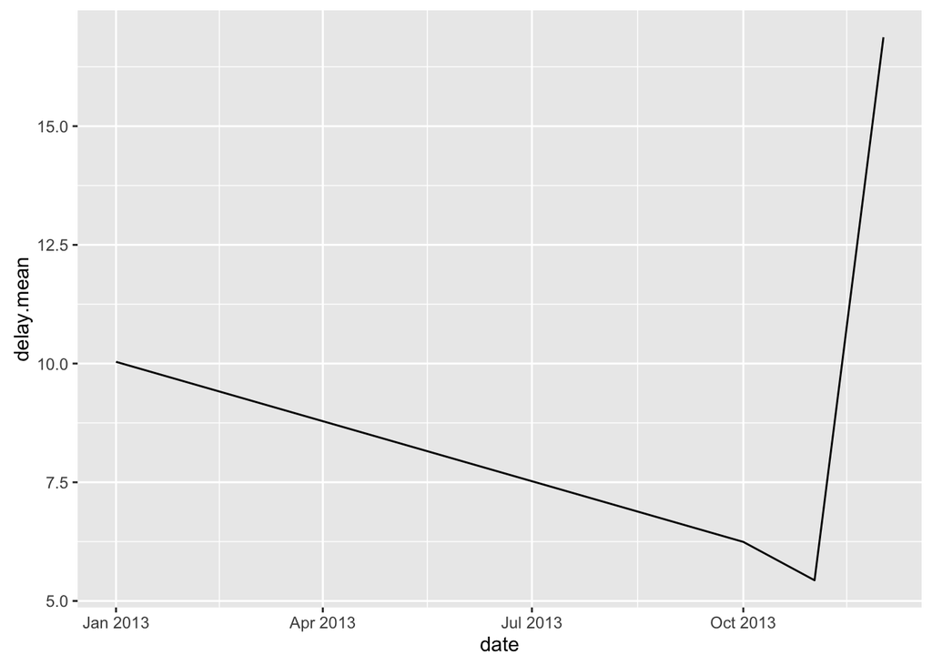

```r
fl.m <-flights %>%
  dplyr::group_by(year, month) %>%
  dplyr::summarize(
    delay.min = min(dep_delay, na.rm = TRUE),
    delay.mean = mean(dep_delay, na.rm = TRUE),
    delay.max = max(dep_delay, na.rm = TRUE)
  )
fl.m$date<- as.Date(paste(fl.m$month, fl.m$year, "01", sep="."), format = "%m.%Y.%d")
ggplot(data=fl.m, aes(x=date, y=delay.mean)) + geom_line()
```

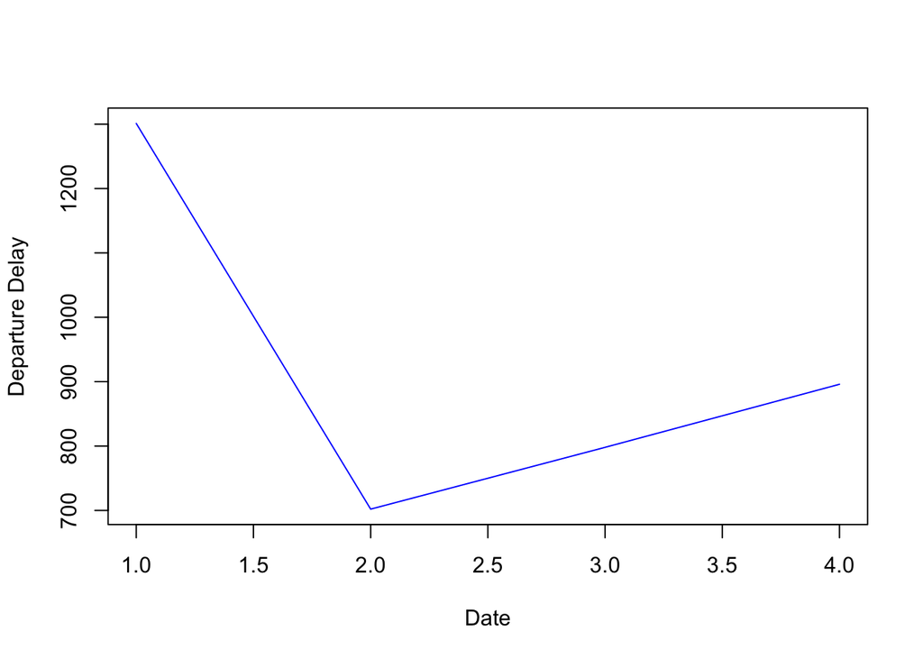

This plot shows the maximum amount of delayed departures over the span of 1 year.

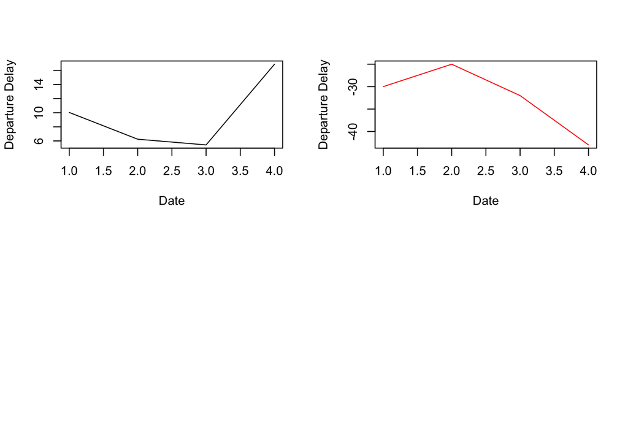

These graphs compare the average amount of departure delayed flights and the minimum over time.

## Part C - Airport Destination

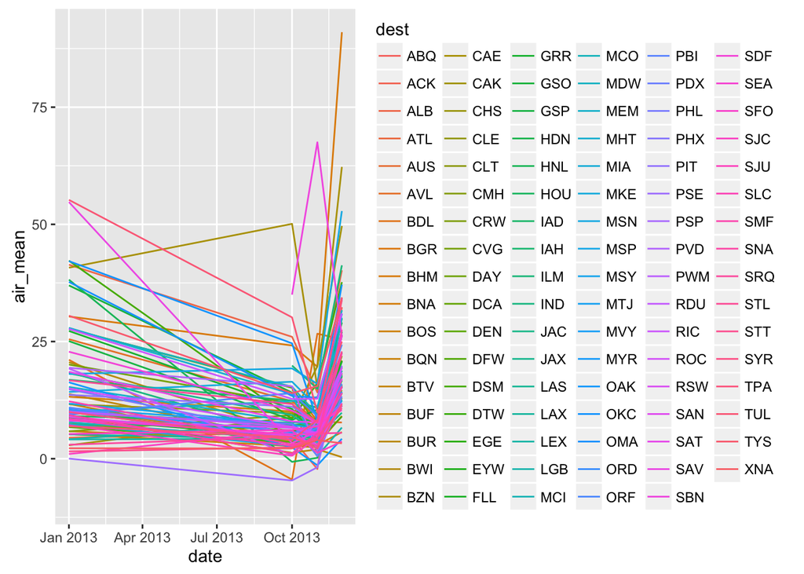

Average Delayed Departures, ggplot

This graphs shows where some locations experience peaks in their average number of delayed flights.

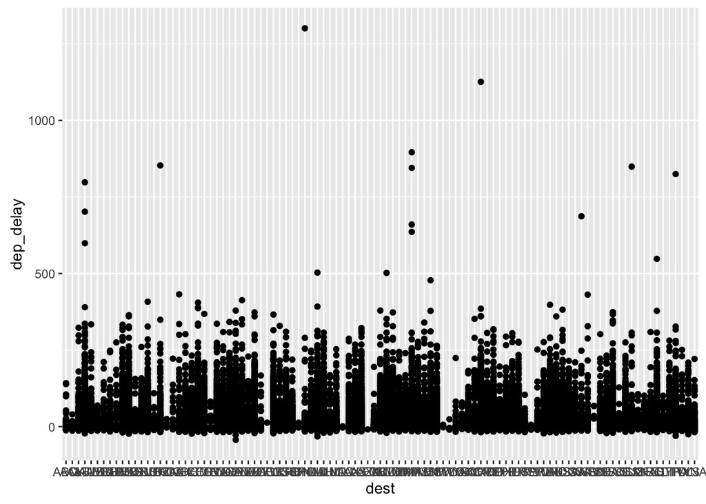

Departure Delay by Destination, ggplot

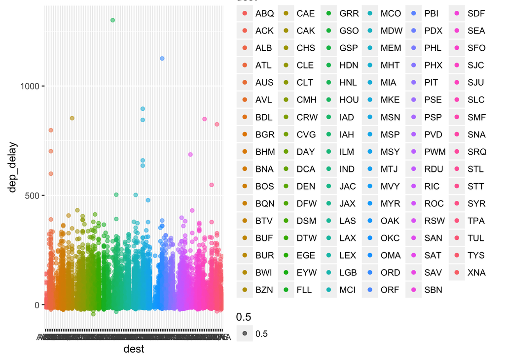

Departure Delay by Destination, ggplot

THis graphs appears to show a unifrom distribution for departure delays and destination.

```
##
## Call:
## lm(formula = a.p.f$can ~ a.p.f$dest)
##
## Residuals:
##      Min       1Q   Median       3Q      Max
## -0.10127 -0.02510 -0.01390 -0.00511  0.99745
##
## Coefficients:
##                 Estimate Std. Error t value Pr(>|t|)
## (Intercept)   -1.149e-14  1.552e-02   0.000 1.000000
## a.p.f$destACK -1.199e-14  3.268e-02   0.000 1.000000
## a.p.f$destALB  6.250e-02  1.931e-02   3.236 0.001212 **
## a.p.f$destATL  1.390e-02  1.564e-02   0.889 0.374223
## a.p.f$destAUS  8.837e-03  1.640e-02   0.539 0.589968
## a.p.f$destAVL  1.013e-01  2.195e-02   4.614 3.96e-06 ***
## a.p.f$destBDL  8.974e-02  2.202e-02   4.076 4.59e-05 ***
## a.p.f$destBGR  2.013e-02  1.920e-02   1.049 0.294294
## a.p.f$destBHM  5.263e-02  2.216e-02   2.375 0.017567 *
## a.p.f$destBNA  3.147e-02  1.584e-02   1.986 0.047024 *
## a.p.f$destBOS  2.505e-02  1.565e-02   1.600 0.109517
## a.p.f$destBQN  6.901e-15  1.794e-02   0.000 1.000000
## a.p.f$destBTV  1.667e-02  1.635e-02   1.019 0.308004
## a.p.f$destBUF  1.640e-02  1.593e-02   1.030 0.303210
## a.p.f$destBUR -4.197e-14  2.012e-02   0.000 1.000000
## a.p.f$destBWI  2.265e-02  1.655e-02   1.368 0.171258
## a.p.f$destBZN  2.874e-15  7.070e-02   0.000 1.000000
## a.p.f$destCAE  9.677e-02  2.923e-02   3.310 0.000933 ***
## a.p.f$destCAK  1.151e-14  1.822e-02   0.000 1.000000
## a.p.f$destCHS  2.128e-02  1.627e-02   1.308 0.190944
## a.p.f$destCLE  2.740e-02  1.598e-02   1.715 0.086436 .
## a.p.f$destCLT  2.069e-02  1.566e-02   1.321 0.186606
## a.p.f$destCMH  4.516e-02  1.609e-02   2.807 0.005000 **
## a.p.f$destCRW  7.875e-15  3.075e-02   0.000 1.000000
## a.p.f$destCVG  3.932e-02  1.604e-02   2.452 0.014213 *
## a.p.f$destDAY  6.436e-02  1.697e-02   3.792 0.000149 ***
## a.p.f$destDCA  4.520e-02  1.573e-02   2.873 0.004068 **
## a.p.f$destDEN  3.310e-03  1.581e-02   0.209 0.834151
## a.p.f$destDFW  4.686e-02  1.575e-02   2.975 0.002933 **
## a.p.f$destDSM  5.528e-02  1.834e-02   3.013 0.002584 **
```

[output cut: 62 more lines]

```
## a.p.f$destSNA  3.876e-03  1.774e-02   0.219 0.827026
## a.p.f$destSRQ  8.523e-03  1.717e-02   0.496 0.619700
## a.p.f$destSTL  3.709e-02  1.596e-02   2.324 0.020124 *
## a.p.f$destSTT  7.463e-03  1.957e-02   0.381 0.702914
## a.p.f$destSYR  3.114e-02  1.660e-02   1.875 0.060781 .
## a.p.f$destTPA  4.911e-03  1.579e-02   0.311 0.755817
## a.p.f$destTUL  5.263e-02  2.100e-02   2.506 0.012219 *
## a.p.f$destTYS  6.154e-02  1.840e-02   3.345 0.000823 ***
## a.p.f$destXNA  1.661e-02  1.744e-02   0.953 0.340798
## ---
## Signif. codes:  0 '***' 0.001 '**' 0.01 '*' 0.05 '.' 0.1 ' ' 1
##
## Residual standard error: 0.1379 on 99899 degrees of freedom
## Multiple R-squared:  0.01273,    Adjusted R-squared:  0.01174
## F-statistic: 12.88 on 100 and 99899 DF,  p-value: < 2.2e-16
```

The regression ressults shows where destination is a statistically significant variable for explaining canceled flights.

# Part D - Characteristics of Plane

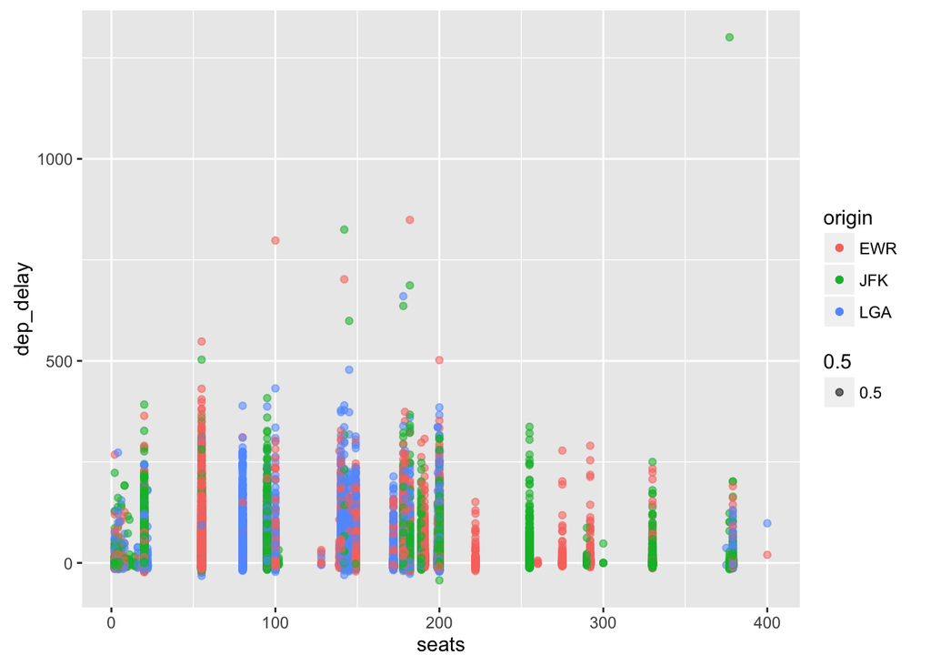

This graph suggests a uniform distribution for the number of seats of a plane and the number of delayed departures. The observations are identified by origin.

```
##
## Call:
## lm(formula = plane.flight$can ~ plane.flight$engines)
##
## Residuals:
##      Min       1Q   Median       3Q      Max
## -0.01572 -0.01195 -0.01195 -0.01195  0.99558
##
## Coefficients:
##                       Estimate Std. Error t value Pr(>|t|)
## (Intercept)           0.019492   0.007872   2.476   0.0133 *
## plane.flight$engines -0.003769   0.003944  -0.956   0.3393
## ---
## Signif. codes:  0 '***' 0.001 '**' 0.01 '*' 0.05 '.' 0.1 ' ' 1
##
## Residual standard error: 0.1088 on 84574 degrees of freedom
##   (15424 observations deleted due to missingness)
## Multiple R-squared:  1.08e-05,   Adjusted R-squared:  -1.026e-06
## F-statistic: 0.9132 on 1 and 84574 DF,  p-value: 0.3393
```

```
##
## Call:
## lm(formula = plane.flight$dep_delay ~ plane.flight$engines)
##
## Residuals:
##     Min      1Q  Median      3Q     Max
##  -52.29  -14.29  -11.29   -2.29 1291.71
##
## Coefficients:
##                      Estimate Std. Error t value Pr(>|t|)
## (Intercept)             5.272      2.545   2.071   0.0383 *
## plane.flight$engines    2.009      1.275   1.576   0.1151
## ---
## Signif. codes:  0 '***' 0.001 '**' 0.01 '*' 0.05 '.' 0.1 ' ' 1
##
## Residual standard error: 34.54 on 83621 degrees of freedom
##   (16377 observations deleted due to missingness)
## Multiple R-squared:  2.969e-05,  Adjusted R-squared:  1.773e-05
## F-statistic: 2.482 on 1 and 83621 DF,  p-value: 0.1151
```

```
##  [1] 377  NA  NA  NA 182  NA 142 100 142 182
```

Number of seats on the top 10 delayed departure flights

```
##  [1] "HA" "MQ" "AA" "MQ" "DL" "AA" "DL" "DL" "DL" "DL"
```

Carriers of top 10 delayed departure flights.